# Statistical Inference Project 1

Frog

Wednesday, August 06, 2014

## Part 1: Simulation of Averages of an Exponential Distribution

In this excercise we are asked to simulate the average of 40 draws from an exponential distribution with lambda=0.2. I decided to do 10.000 simulations of this.

```r
g=c()
lambda = 0.2

for (i in 1:10000) {
    r<-mean(rexp(40,lambda))
    g=c(g,r)
}

gd<-as.data.frame(g)
```

### 1. Show where the distribution is centered at and compare it to the theoretical center of the distribution.

```r
mean(g)
```

```
## [1] 5.009
```

```r
1/lambda
```

```
## [1] 5
```

The theoretial mean of the exponential distribution is 1/lambda so we can see that the mean of the simulated averages has the same mean as the original distribution.

### 2. Show how variable it is and compare it to the theoretical variance of the distribution.

```r
1/lambda  # sd of exponential
```

```
## [1] 5
```

```r
1/lambda / sqrt(40) # theoretical sd of simulation
```

```
## [1] 0.7906
```

```r
sd(g) # sd of simulation
```

```
## [1] 0.794
```

We see that the variation of the averages follows the de Moivre equation depending on the square root of the sample size. In other words it is narrower than the original variation of the distribution. Here we are using standard deviation. Variation is the same but squared.

### 3. Show that the distribution is approximately normal.

Aha! That I can do.

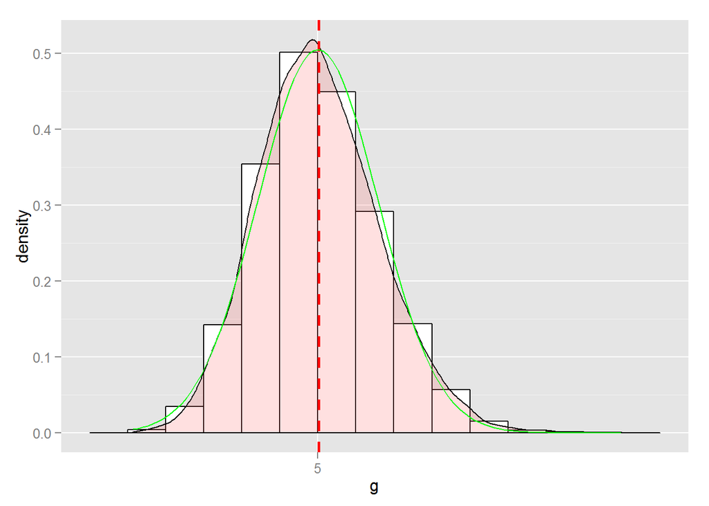

```r
library(ggplot2)
ggplot(gd,aes(x=g)) + geom_histogram(aes(y=..density..),binwidth=.5,colour="black",fill="white") +
    geom_density(alpha=.2,fill="#FF6666") +
    geom_vline(aes(xintercept=mean(g, na.rm=T)),   # Ignore NA values for mean
               color="red", linetype="dashed", size=1) +
    scale_x_continuous(breaks=seq(0,60,5)) +
    stat_function(colour="green",geom="line", fun=dnorm, arg=list(mean=1/0.2, sd=0.79))
```

We see that the distribution has a normal shape. I overlayed a normal distribution (green) to show how close it is, they are almost the same curves!

WE can also see that the distribution of the averages of the 40 exponential draws is centered in 5 which is the same theoretical mean as the exponential distribution (1/lambda).

### 4. Evaluate the coverage of the confidence interval for 1/lambda: x+/- 1.96 s/sqrt(n)

```r
pt(1.96,39)
```

```
## [1] 0.9714
```

Thank you for reading and see you in the next course!